# MindTheGap

Callum Hollywood

28 December 2017

## A Brief Exploratory Data Analysis of the Gapminder Dataset

## Shipped with the R Gapminder Package

#### We can get a feel for the general composition of this dataset

#### by looking at both ends of the dataframe, as it is shipped. Supported by some

#### additional basic descriptive statistics: …

```r
head(gapminder)
```

```
## # A tibble: 6 x 6
##       country continent  year lifeExp      pop gdpPercap
##        <fctr>    <fctr> <int>   <dbl>    <int>     <dbl>
## 1 Afghanistan      Asia  1952  28.801  8425333  779.4453
## 2 Afghanistan      Asia  1957  30.332  9240934  820.8530
## 3 Afghanistan      Asia  1962  31.997 10267083  853.1007
## 4 Afghanistan      Asia  1967  34.020 11537966  836.1971
## 5 Afghanistan      Asia  1972  36.088 13079460  739.9811
## 6 Afghanistan      Asia  1977  38.438 14880372  786.1134
```

```r
tail(gapminder)
```

```
## # A tibble: 6 x 6
##    country continent  year lifeExp      pop gdpPercap
##     <fctr>    <fctr> <int>   <dbl>    <int>     <dbl>
## 1 Zimbabwe    Africa  1982  60.363  7636524  788.8550
## 2 Zimbabwe    Africa  1987  62.351  9216418  706.1573
## 3 Zimbabwe    Africa  1992  60.377 10704340  693.4208
## 4 Zimbabwe    Africa  1997  46.809 11404948  792.4500
## 5 Zimbabwe    Africa  2002  39.989 11926563  672.0386
## 6 Zimbabwe    Africa  2007  43.487 12311143  469.7093
```

```r
str(gapminder)
```

```
## Classes 'tbl_df', 'tbl' and 'data.frame':    1704 obs. of  6 variables:
##  $ country  : Factor w/ 142 levels "Afghanistan",..: 1 1 1 1 1 1 1 1 1 1 ...
##  $ continent: Factor w/ 5 levels "Africa","Americas",..: 3 3 3 3 3 3 3 3 3 3 ...
##  $ year     : int  1952 1957 1962 1967 1972 1977 1982 1987 1992 1997 ...
##  $ lifeExp  : num  28.8 30.3 32 34 36.1 ...
##  $ pop      : int  8425333 9240934 10267083 11537966 13079460 14880372 12881816 13867957 16317921 22227415 ...
##  $ gdpPercap: num  779 821 853 836 740 ...
```

```r
summary(gapminder)
```

```
##         country        continent        year         lifeExp
##  Afghanistan:  12   Africa  :624   Min.   :1952   Min.   :23.60
##  Albania    :  12   Americas:300   1st Qu.:1966   1st Qu.:48.20
##  Algeria    :  12   Asia    :396   Median :1980   Median :60.71
##  Angola     :  12   Europe  :360   Mean   :1980   Mean   :59.47
##  Argentina  :  12   Oceania : 24   3rd Qu.:1993   3rd Qu.:70.85
##  Australia  :  12                  Max.   :2007   Max.   :82.60
##  (Other)    :1632
##       pop               gdpPercap
##  Min.   :     60011   Min.   :   241.2
##  1st Qu.:   2793664   1st Qu.:  1202.1
##  Median :   7023596   Median :  3531.8
##  Mean   :  29601212   Mean   :  7215.3
##  3rd Qu.:  19585222   3rd Qu.:  9325.5
##  Max.   :1318683096   Max.   :113523.1
##
```

#### Data Summary: –

#### It looks like we have over 1700 observations detailing measurements

#### for 3 key features, 1) Life Expectancy, 2) Population and 3) GDP per Capita

#### for 142 countries, which have also been labeled with their appropriate continent.

#### The duration for capturing this data appears to be from 1952 to 2007 and has been captured

#### at 5 year intervals.

#### We can proceed to examine the gapminder features, by country, over time: …

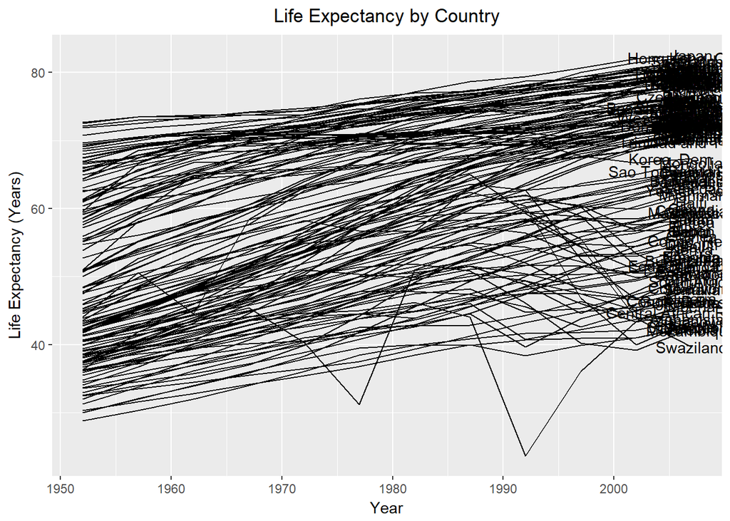

```r
#========================
# plot lifeExp over the survey duration, by country
#========================

ggplot(gapminder, aes(x = year, y = lifeExp, group = country)) +
  geom_line() +
  theme(legend.position = "none") +
  ggtitle("Life Expectancy by Country") +
  theme(plot.title = element_text(hjust = 0.5)) +
  geom_text(data = gapminder[gapminder$year == 2007,], aes(label = country)) +
  xlab("Year") +
  ylab("Life Expectancy (Years)")
```

#### Looks like there’s a lot going on with all the countries represented above.

#### What we can discern though is that there appears to be a general increase in

#### life expectancy, though there are definitely some countries that seem to buck that trend.

#### We will return to this and examine in greater depth!

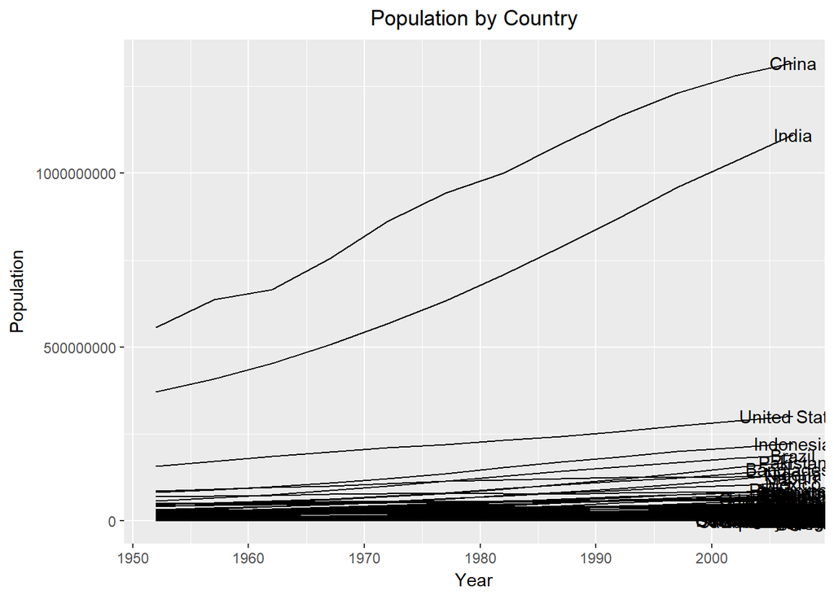

```r
#========================
# plot pop over the survey duration, by country
#========================

ggplot(gapminder, aes(year, pop, group = country)) +
  geom_line() +
  theme(legend.position = "none") +
  ggtitle("Population by Country") +
  geom_text(data = gapminder[gapminder$year == 2007,], aes(label = country)) +
  theme(plot.title = element_text(hjust = 0.5)) +
  xlab("Year") +
  ylab("Population")
```

#### Jeez Louise - Look at the population climbs by China and India!

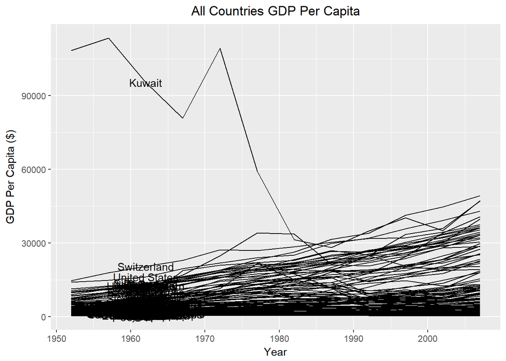

```r
#========================
# plot gdpPercap over the survey duration, by country
#========================

ggplot(gapminder, aes(year, gdpPercap, group = country)) +
  geom_line() +
  theme(legend.position = "none") +
  ggtitle("All Countries GDP Per Capita") +
  geom_text(data = gapminder[gapminder$year == 1962,], aes(label = country)) +
  theme(plot.title = element_text(hjust = 0.5)) +
  xlab("Year") +
  ylab("GDP Per Capita ($)")
```

#### In generel, i.e. omitting the GDP per Capita of Kuwait, we can see that this feature

#### tends to be increasing over time. It would be interesting to see what is going on with Kuwait later.

#### And if there are any other countries that have a reduced GDP

#### The graphs above show the gapminder features at the country level, and it all got

#### a bit busy on the eyes. Let’s aggregate to the ‘Continent’ level: …

```r
continent_view <- gapminder %>%
  group_by(continent, year) %>%
  summarise(mean_lifeExp = mean(lifeExp, na.rm = T),
            mean_pop = mean(pop, na.rm = T),
            mean_gdpPercap = mean(gdpPercap, na.rm = T))

head(continent_view)
```

```
## Source: local data frame [6 x 5]
## Groups: continent [1]
##
## # A tibble: 6 x 5
##   continent  year mean_lifeExp mean_pop mean_gdpPercap
##      <fctr> <int>        <dbl>    <dbl>          <dbl>
## 1    Africa  1952     39.13550  4570010       1252.572
## 2    Africa  1957     41.26635  5093033       1385.236
## 3    Africa  1962     43.31944  5702247       1598.079
## 4    Africa  1967     45.33454  6447875       2050.364
## 5    Africa  1972     47.45094  7305376       2339.616
## 6    Africa  1977     49.58042  8328097       2585.939
```

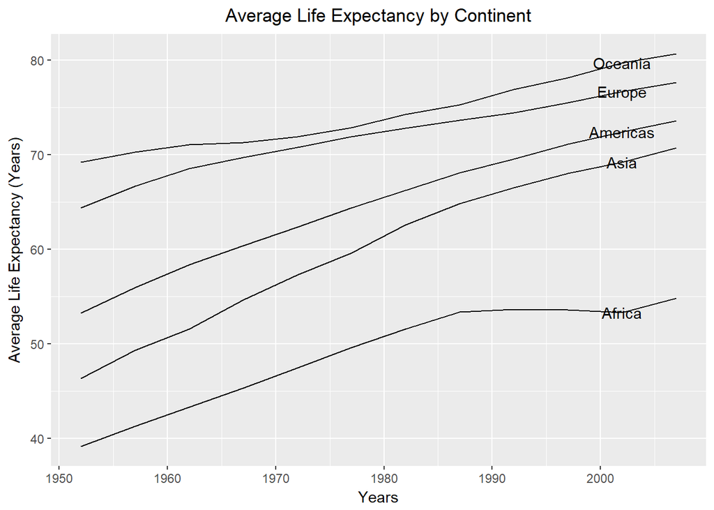

```r
#========================
# plot mean_lifeExp over the survey duration, by continent
#========================

continent_view %>%
  select(-c(mean_pop, mean_gdpPercap)) %>%
  ggplot(aes(year, mean_lifeExp, group = continent)) +
  geom_line() +
  ggtitle("Average Life Expectancy by Continent") +
  geom_text(data = continent_view %>% filter(year == 2002) ,
            aes(label = continent))+
  theme(plot.title = element_text(hjust = 0.5)) +
  xlab("Years") +
  ylab("Average Life Expectancy (Years)")
```

#### Across the board we can see that life expecnacy is on the increase and that there appears to

#### be a distinct difference in average life expectancy across the continents. Of particular note

#### is that not ony is Africa trailing, it appears to have levelled off through the late 80’s and 90’s.

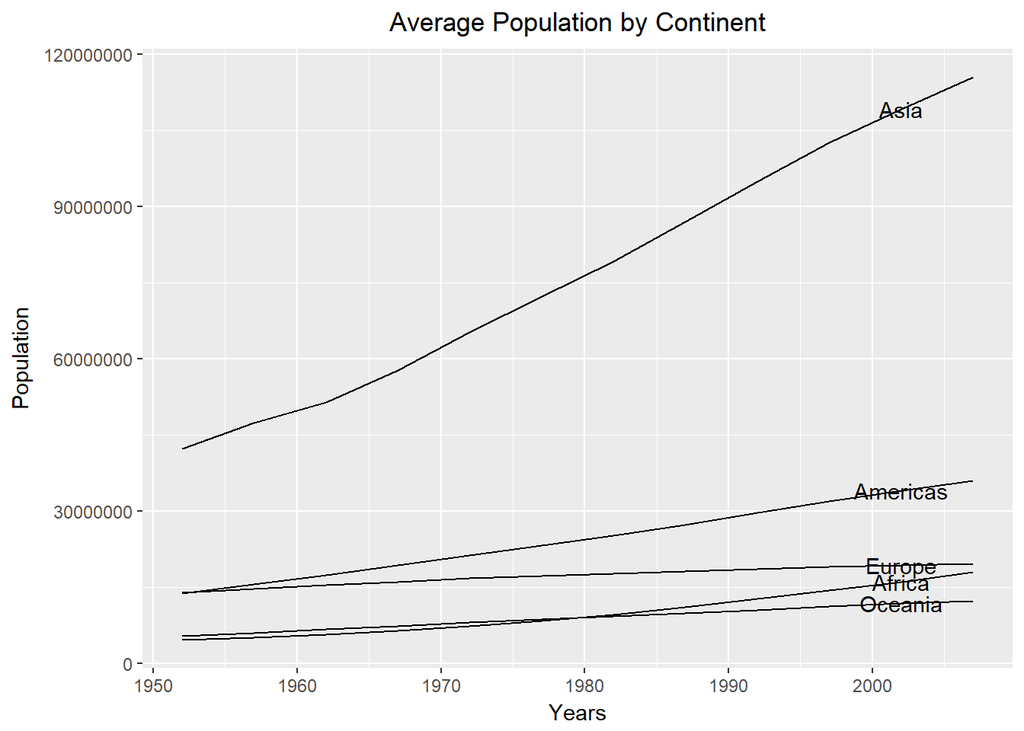

```r
#========================
# plot mean_pop over the survey duration, by continent
#========================

continent_view %>%
  select(-c(mean_lifeExp, mean_gdpPercap)) %>%
  ggplot(aes(year, mean_pop, group = continent)) +
  geom_line() +
  ggtitle("Average Population by Continent") +
  geom_text(data = continent_view %>% filter(year == 2002),
            aes(label = continent)) +
  xlab("Years") +
  ylab("Population") +
  theme(plot.title = element_text(hjust = 0.5))
```

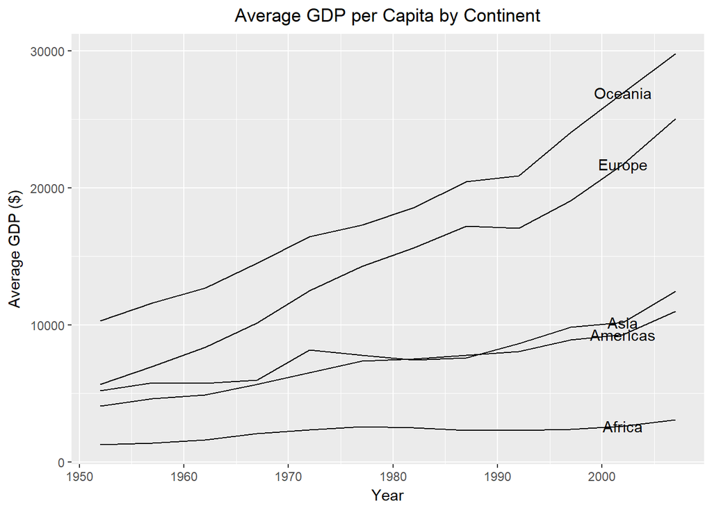

```r
#========================
# plot mean_gdpPercap over the survey duration, by continent
#========================

continent_view %>%
  select(-c(mean_lifeExp, mean_pop)) %>%
  ggplot(aes(year, mean_gdpPercap, group = continent)) +
  geom_line() +
  ggtitle("Average GDP per Capita by Continent") +
  geom_text(data = continent_view %>% filter(year == 2002),
            aes(label = continent)) +
  theme(plot.title = element_text(hjust = 0.5)) +
  xlab("Year") +
  ylab("Average GDP ($)")
```

#### It appears that the average GDP in both Oceania and Eurpoe is outpacing

#### Asia and the Americas, which are all pulling away from Africa

#### Africa definitely seems to out of step with the other continents.

#### Let’s have a look at the continents individually to see how the gapminder features are interplaying:…

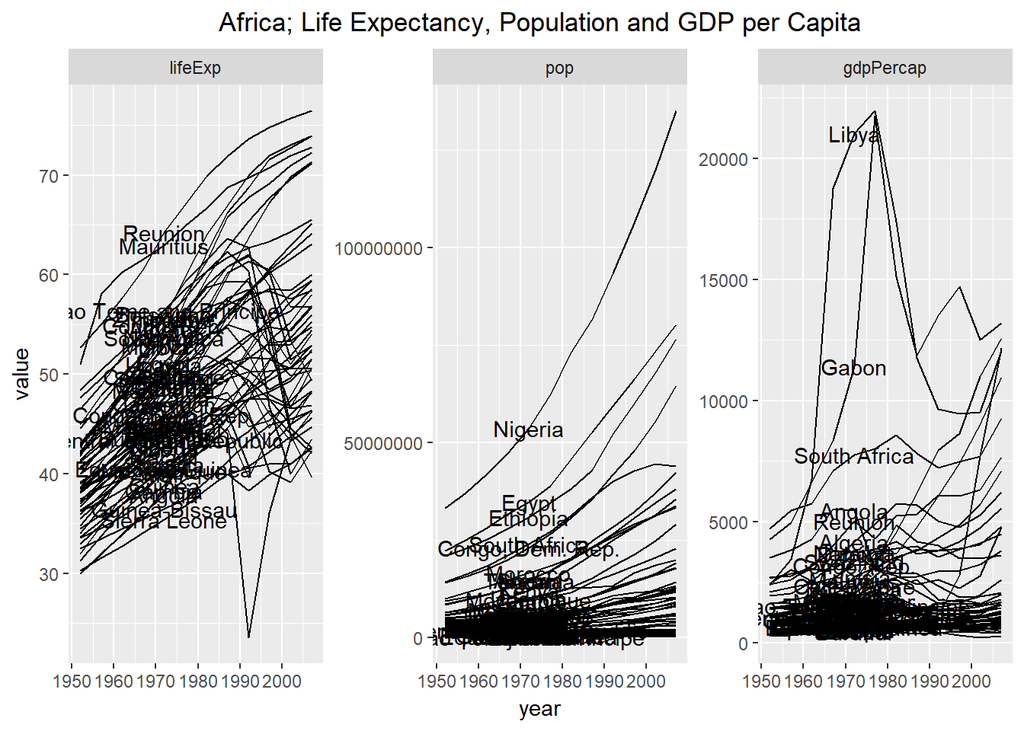

```r
africa <- gapminder %>% filter(continent == "Africa") %>% select(-c(continent))

africa_melt <- melt(africa,
                    id.vars = c("country", "year"),
                    variable.name = "feature",
                    value.name = "value")

africa_melt %>%
  ggplot(aes(year, value, group = country)) +
  geom_line() +
  facet_wrap(~ feature, scales = "free_y") +
  geom_text(data = africa_melt %>% filter(year == 1972),
            aes(label = country)) +
  ggtitle("Africa; Life Expectancy, Population and GDP per Capita") +
  theme(plot.title = element_text(hjust = 0.5))
```

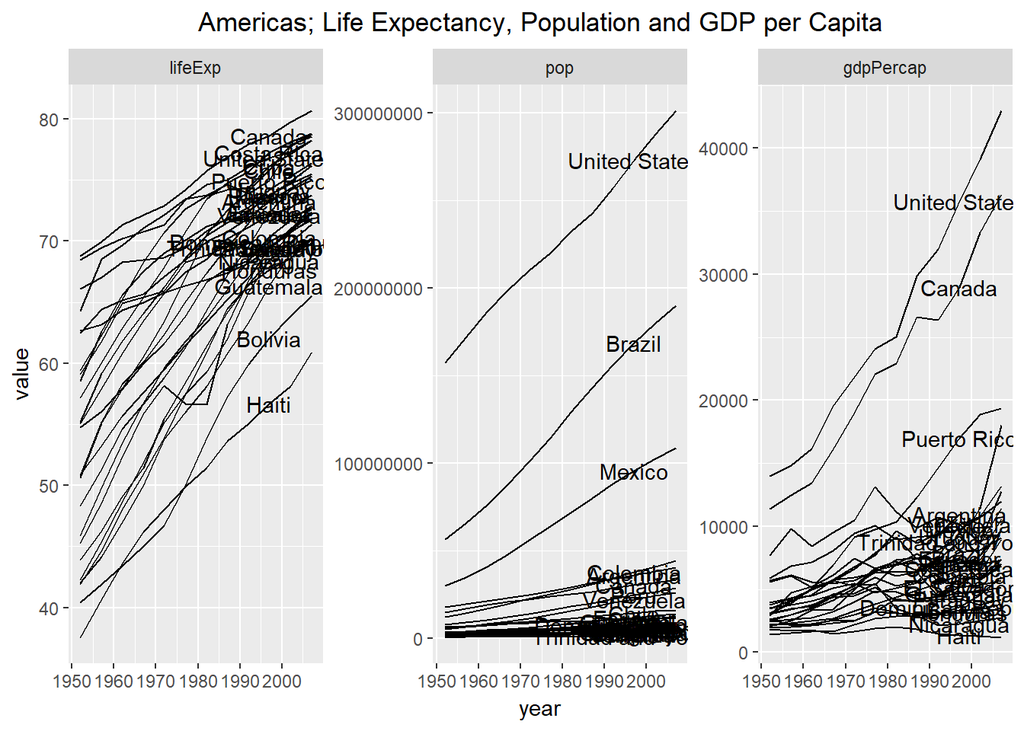

```r
americas <- gapminder %>% filter(continent == "Americas") %>%  select(-c(continent))

americas_melt <- melt(americas,
                      id.vars = c("country", "year"),
                      variable.name = 'feature',
                      value.name = "value")

americas_melt %>%
  ggplot(aes(year, value, group = country)) +
  geom_line() +
  facet_wrap(~feature, scales = 'free_y') +
  geom_text(data = americas_melt %>% filter(year == 1997),
            aes(label = country)) +
  ggtitle("Americas; Life Expectancy, Population and GDP per Capita") +
  theme(plot.title = element_text(hjust = 0.5))
```

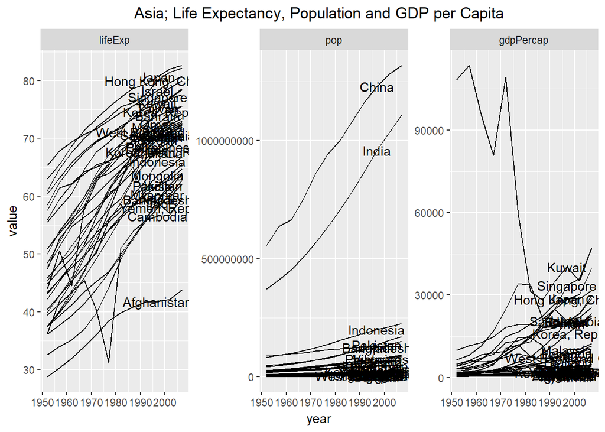

```r
asia <- gapminder %>% filter(continent == "Asia") %>% select(-c(continent))

asia_melt <- melt(asia,
                  id.vars = c("country", "year"),
                  variable.name = "feature",
                  value.name = "value")

asia_melt %>%
  ggplot(aes(year, value, group = country)) +
  geom_line() +
  facet_wrap(~ feature, scales = "free_y") +
  geom_text(data = asia_melt %>% filter(year == 1997),
            aes(label = country)) +
  ggtitle("Asia; Life Expectancy, Population and GDP per Capita") +
  theme(plot.title = element_text(hjust = 0.5))
```

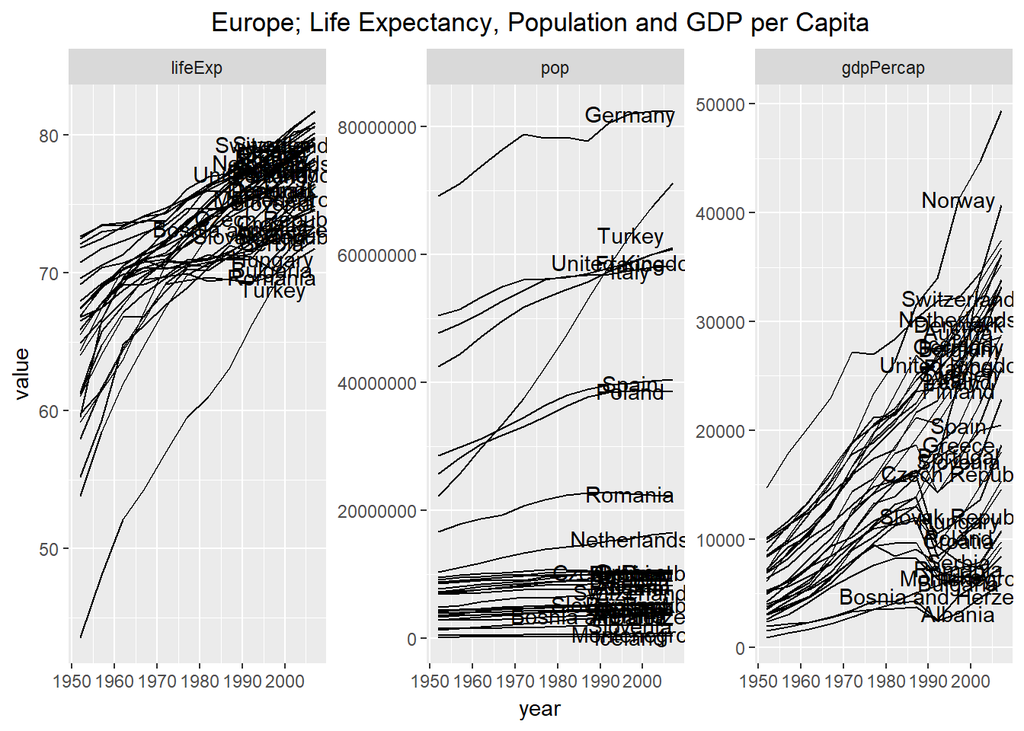

```r
europe <- gapminder %>% filter(continent == "Europe") %>% select(-c(continent))

europe_melt <- melt(europe,
                    id.vars = c("country", "year"),
                    variable.name = "feature",
                    value.name = "value")


europe_melt %>%
  ggplot(aes(year, value, group = country)) +
  geom_line() +
  facet_wrap(~ feature, scales = 'free_y') +
  geom_text(data = europe_melt %>% filter(year == 1997),
            aes(label = country)) +
  ggtitle("Europe; Life Expectancy, Population and GDP per Capita") +
  theme(plot.title = element_text(hjust = 0.5))
```

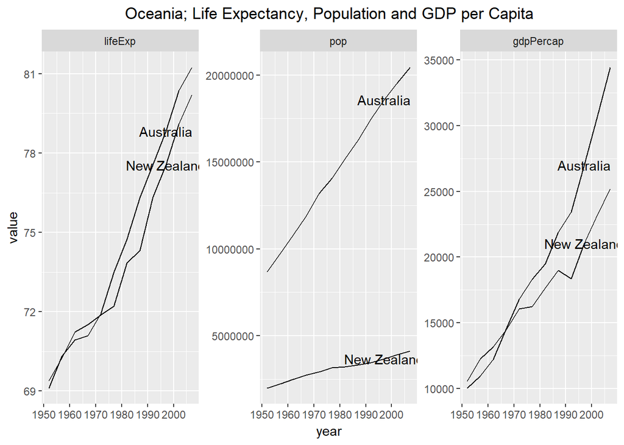

```r
oceania <- gapminder %>% filter(continent == "Oceania") %>% select(-c(continent))

oceania_melt <- melt(oceania,
                    id.vars = c("country", "year"),
                    variable.name = "feature",
                    value.name = "value")

oceania_melt %>%
  ggplot(aes(year, value, group = country)) +
  geom_line() +
  facet_wrap(~ feature, scales = "free_y") +
  geom_text(data = oceania_melt %>% filter(year == 1997),
          aes(label = country)) +
  ggtitle("Oceania; Life Expectancy, Population and GDP per Capita") +
  theme(plot.title = element_text(hjust = 0.5))
```

#### Africa still requires further examination. Let’s have a look at all the countries where there was a dip in life expectancy observed, at some/any point in the data:…

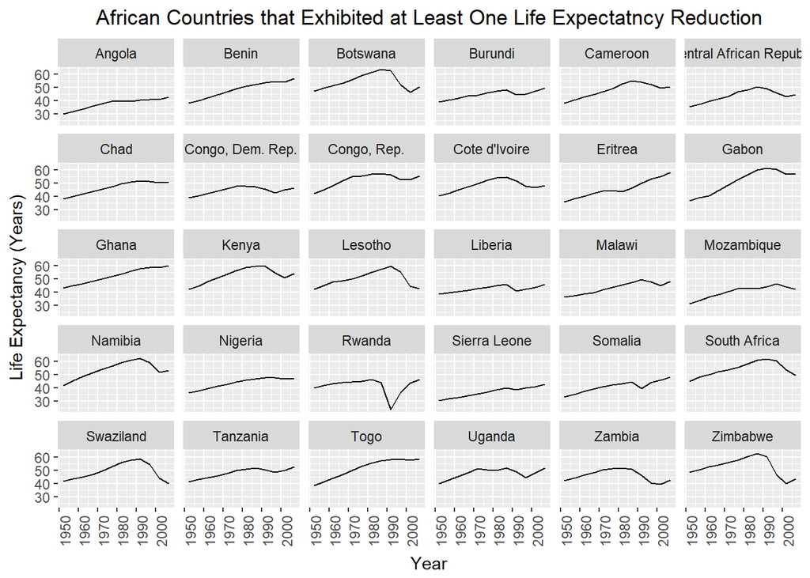

```r
##################################################################
# Drill into Africa and examine at the country level
# Filter out countries that never took a dip in lifeExp at any point
# Facet for better visuals
##################################################################

lifeexpdrops <- gapminder::gapminder %>%
  filter(continent == "Africa") %>%
  select(-c(continent, pop, gdpPercap)) %>%
  spread(year, lifeExp)

indx <- colSums(apply(lifeexpdrops %>% select(-c(country)), 1L, diff) > 0L) == (ncol(lifeexpdrops%>% select(-c(country))) - 1L)
lifeexpdrops <-  lifeexpdrops[!indx,]$country

gapminder::gapminder %>%
  filter(continent == "Africa") %>%
  filter(country %in% lifeexpdrops) %>%
  select(-c(continent)) %>%
  ggplot(aes(year, lifeExp, group = country)) +
  geom_line() +
  facet_wrap(~ country) +
  theme(axis.text.x = element_text(angle = 90, hjust = 1)) +
  ggtitle("African Countries that Exhibited at Least One Life Expectatncy Reduction") +
  theme(plot.title = element_text(hjust = 0.5)) +
  xlab("Year") +
  ylab("Life Expectancy (Years)")
```

#### Let’s start to visualise with a map or two:…

```r
lifeexpdrops <- gapminder::gapminder %>%
  filter(continent == "Africa") %>%
  select(-c(continent, pop, gdpPercap)) %>%
  spread(year, lifeExp)

indx <- colSums(apply(lifeexpdrops %>% select(-c(country)), 1L, diff) > 0L) == (ncol(lifeexpdrops%>% select(-c(country))) - 1L)
lifeexpdrops <-  lifeexpdrops[!indx,]$country

africa <- gapminder::gapminder %>%
  filter(continent == "Africa") %>%
  select(-c(continent)) %>%
  filter(year == 2002) %>%
  mutate(lifeExpDrop = if_else(country %in% lifeexpdrops, "dropped at least once", "has never dropped"))

sPDF <- joinCountryData2Map(africa,
                            joinCode = "NAME",
                            nameJoinColumn = "country")
```

```
## 51 codes from your data successfully matched countries in the map
## 1 codes from your data failed to match with a country code in the map
## 192 codes from the map weren't represented in your data
```

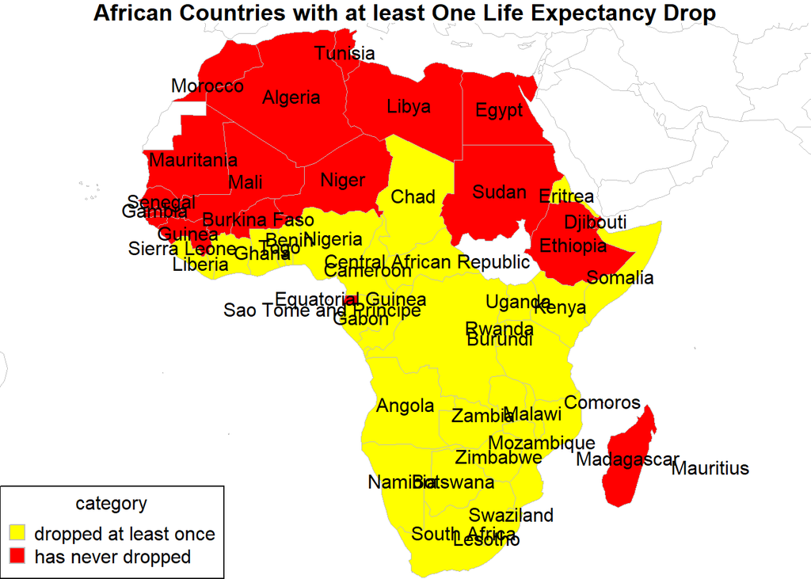

```r
par(mai = c(0,0,0.2,0), xaxs="i", yaxs = "i")
mapCountryData(sPDF,
               nameColumnToPlot = "lifeExpDrop",
               catMethod="categorical",
               numCats = 2,
               addLegend =T,
               mapTitle = "African Countries with at least One Life Expectancy Drop",
               mapRegion = "Africa")

country_coord<-data.frame(coordinates(sPDF),stringsAsFactors=F)
country_coord_B <- country_coord[row.names(country_coord) %in% africa$country,]

text(x = country_coord_B$X1, y = country_coord_B$X2,
     labels = row.names(country_coord_B))
```

```r
lifeexpdrops <- gapminder::gapminder %>%
  select(-c(continent, pop, gdpPercap)) %>%
  spread(year, lifeExp)

indx <- colSums(apply(lifeexpdrops %>% select(-c(country)), 1L, diff) > 0L) == (ncol(lifeexpdrops%>% select(-c(country))) - 1L)
lifeexpdrops <-  lifeexpdrops[!indx,]$country

worldLifeExpDrop <- gapminder::gapminder %>%
  select(-c(continent)) %>%
  filter(year == 2002) %>%
  mutate(lifeExpDrop = if_else(country %in% lifeexpdrops, "dropped at least once", "has never dropped"))


worldLifeExpDropExcptAfrica <- worldLifeExpDrop %>%
  filter(lifeExpDrop == "dropped at least once") %>%
  filter(!country %in% africa$country)

sPDF_World <- joinCountryData2Map(worldLifeExpDrop,
                            joinCode = "NAME",
                            nameJoinColumn = "country")
```

```
## 139 codes from your data successfully matched countries in the map
## 3 codes from your data failed to match with a country code in the map
## 104 codes from the map weren't represented in your data
```

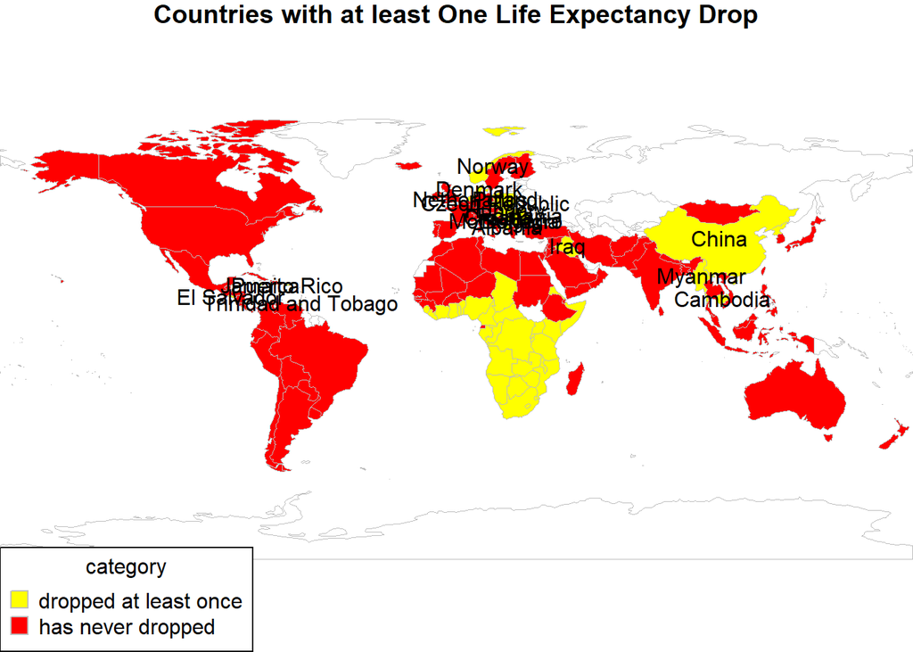

```r
par(mai = c(0,0,0.2,0), xaxs="i", yaxs = "i")
mapCountryData(sPDF_World,
               nameColumnToPlot = "lifeExpDrop",
               catMethod="categorical",
               numCats = 2,
               addLegend =T,
               mapTitle = "Countries with at least One Life Expectancy Drop"
               )

#country_coord <- data.frame(coordinates(sPDF_World),stringsAsFactors=F)
country_coord_C <- country_coord[row.names(country_coord) %in% worldLifeExpDropExcptAfrica$country,]

text(x = country_coord_C$X1, y = country_coord_C$X2,
     labels = row.names(country_coord_C))
```

```r
pop_drops <- gapminder::gapminder %>%
  select(-c(continent, lifeExp, gdpPercap)) %>%
  spread(year, pop)

indx <- colSums(apply(pop_drops %>% select(-c(country)), 1L, diff) > 0L) == (ncol(pop_drops%>% select(-c(country))) - 1L)
pop_drops <-  pop_drops[!indx,]$country

world_popdrops <- gapminder::gapminder %>%
  select(-c(continent)) %>%
  filter(year == 2002) %>%
  mutate(pop_drops = if_else(country %in% pop_drops, "dropped at least once", "has never dropped"))

world_popdrops_slim <- world_popdrops[world_popdrops$pop_drops == 'dropped at least once',]

sPDF_worldpopdrop <- joinCountryData2Map(world_popdrops,
                                  joinCode = "NAME",
                                  nameJoinColumn = "country")
```

```
## 139 codes from your data successfully matched countries in the map
## 3 codes from your data failed to match with a country code in the map
## 104 codes from the map weren't represented in your data
```

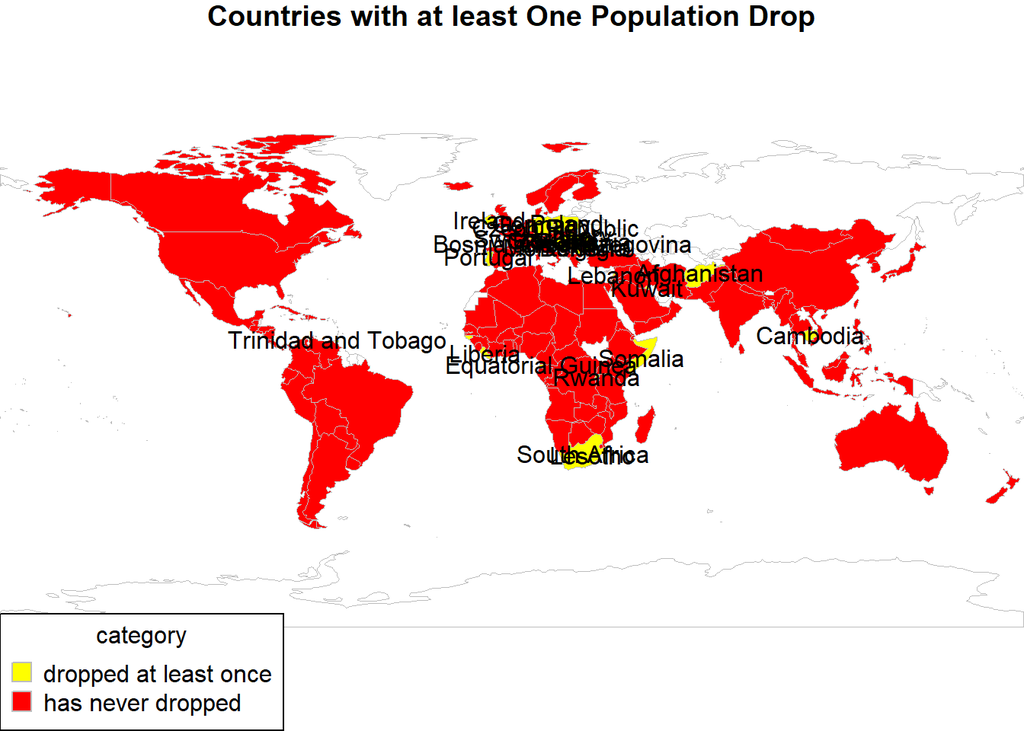

```r
par(mai = c(0,0,0.2,0), xaxs="i", yaxs = "i")
mapCountryData(sPDF_worldpopdrop,
               nameColumnToPlot = "pop_drops",
               catMethod="categorical",
               numCats = 2,
               addLegend =T,
               mapTitle = "Countries with at least One Population Drop")

#country_coord <- data.frame(coordinates(sPDF_World),stringsAsFactors=F)
country_coord_D <- country_coord[row.names(country_coord) %in% world_popdrops_slim$country,]

text(x = country_coord_D$X1, y = country_coord_D$X2,
     labels = row.names(country_coord_D))
```

```r
gdp_drops <- gapminder::gapminder %>%
  select(-c(continent, lifeExp, pop)) %>%
  spread(year, gdpPercap)

indx <- colSums(apply(gdp_drops %>% select(-c(country)), 1L, diff) > 0L) == (ncol(gdp_drops%>% select(-c(country))) - 1L)
gdp_drops <-  gdp_drops[!indx,]$country

world_gdpdrops <- gapminder::gapminder %>%
  select(-c(continent)) %>%
  filter(year == 2002) %>%
  mutate(gdp_drops = if_else(country %in% gdp_drops, "dropped at least once", "has never dropped"))

world_gdpdrops_slim <- world_gdpdrops[world_gdpdrops$gdp_drops == 'dropped at least once',]


sPDF_worldgdpdrop <- joinCountryData2Map(world_gdpdrops,
                                         joinCode = "NAME",
                                         nameJoinColumn = "country")
```

```
## 139 codes from your data successfully matched countries in the map
## 3 codes from your data failed to match with a country code in the map
## 104 codes from the map weren't represented in your data
```

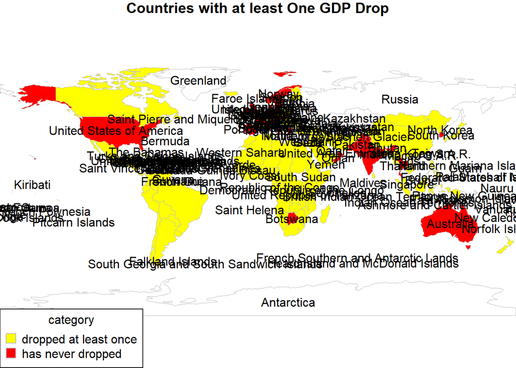

```r
par(mai = c(0,0,0.2,0), xaxs="i", yaxs = "i")
mapCountryData(sPDF_worldgdpdrop,
               nameColumnToPlot = "gdp_drops",
               catMethod="categorical",
               numCats = 2,
               addLegend =T,
               mapTitle = "Countries with at least One GDP Drop")

#country_coord <- data.frame(coordinates(sPDF_World),stringsAsFactors=F)
country_coord_E <- country_coord[!row.names(country_coord) %in% world_gdpdrops_slim$country,]

text(x = country_coord_E$X1, y = country_coord_E$X2,
     labels = row.names(country_coord_E))
```

#### It appears that with respect to GDP it is not unusual to have a dip in GDP year on year,

#### for many countries. Let’s instead have a look to see if any countries have GDPs in 2007 that

#### are less than our starting point in 1952: …

```r
gdp_world_drops <- gapminder::gapminder %>%
  filter(year %in% c(1952, 2007)) %>%
  select(-c(lifeExp, pop, continent)) %>%
  spread(year, gdpPercap) %>%
  mutate(gdp_reduced = `2007` - `1952`) %>%
  mutate(gdp_reduced_cat = if_else(gdp_reduced < 0, "Has Reduced Overall", "Has Increased Overall")) %>%
  filter(gdp_reduced_cat == "Has Reduced Overall")

gdp_world_drops %>% select(-c(gdp_reduced_cat))
```

```
## # A tibble: 12 x 4
##                     country      `1952`     `2007`  gdp_reduced
##                      <fctr>       <dbl>      <dbl>        <dbl>
##  1 Central African Republic   1071.3107   706.0165   -365.29418
##  2                  Comoros   1102.9909   986.1479   -116.84306
##  3         Congo, Dem. Rep.    780.5423   277.5519   -502.99047
##  4                 Djibouti   2669.5295  2082.4816   -587.04791
##  5                    Haiti   1840.3669  1201.6372   -638.72978
##  6                   Kuwait 108382.3529 47306.9898 -61075.36312
##  7                  Liberia    575.5730   414.5073   -161.06565
##  8               Madagascar   1443.0117  1044.7701   -398.24159
##  9                Nicaragua   3112.3639  2749.3210   -363.04298
## 10                    Niger    761.8794   619.6769   -142.20248
## 11             Sierra Leone    879.7877   862.5408    -17.24698
## 12                  Somalia   1135.7498   926.1411   -209.60877
```

```r
sPDF_gdp_world_drops <- joinCountryData2Map(gdp_world_drops,
                                            joinCode = "NAME",
                                            nameJoinColumn = "country")
```

```
## 12 codes from your data successfully matched countries in the map
## 0 codes from your data failed to match with a country code in the map
## 231 codes from the map weren't represented in your data
```

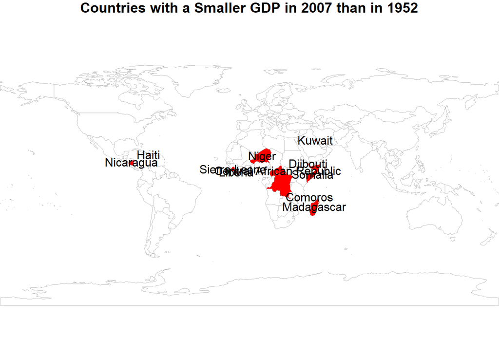

```r
par(mai = c(0,0,0.2,0), xaxs="i", yaxs = "i")
mapCountryData(sPDF_gdp_world_drops,
               nameColumnToPlot = "gdp_reduced_cat",
               catMethod="categorical",
               numCats = 2,
               addLegend =F,
               mapTitle = "Countries with a Smaller GDP in 2007 than in 1952"
)

#country_coord <- data.frame(coordinates(sPDF_gdp_world_drops),stringsAsFactors=F)
country_coord_F <- country_coord[row.names(country_coord) %in% sPDF_gdp_world_drops$country,]

text(x = country_coord_F$X1, y = country_coord_F$X2,
     labels = row.names(country_coord_F))
```